[figure not shown]

# Poison in Politics? Look at Your Own Records First

Labour and the Conservatives say a handful of Reform councillors' words make the whole party unfit for office. Apply the same test to their own people, and to their convictions for rape, child abuse, assault and fraud.

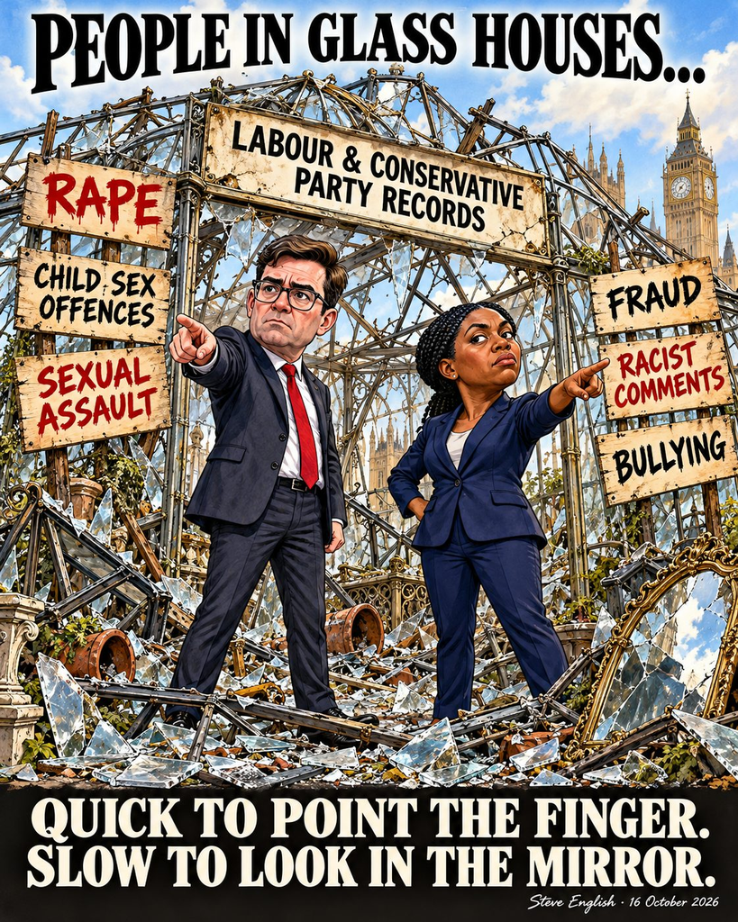

**PURPOSE / MISSION:** To test the claim that a few individuals' conduct makes an entire party "poison", by applying it consistently to every party, using court records, parliamentary findings and mainstream reporting.

On 15 October ITV News reported the fallout from its undercover investigation, *Undercover: A Year in Reform*. Reporters spent months alongside Reform candidates and councillors during the May local elections and four by-elections. What they recorded is ugly and indefensible. One Solihull councillor called Asian families "absolute parasites". A Bromley councillor described black children as "animals". A Tameside councillor talked about training young men to go "street-by-street" rounding up migrants. Reform says investigations have begun, and several of those filmed have already left the party.

Nobody should defend those words, and this article does not. But the reaction from Westminster deserves the same scrutiny.

## The lectures

Prime Minister Andy Burnham told journalists:

> "We've allowed a poison into our politics in recent years and it's time to draw a line on it."

He said he hoped Reform would take "immediate and firm action".

Labour chair Bridget Phillipson went further. She said Farage and his party are "determined to poison our politics" and that the evidence showed "why Nigel Farage and Reform are completely unfit for office".

A Conservative Party spokesman said the footage showed Farage had failed to make Reform ready for government: "These sorry individuals are proof he has failed."

Liam Byrne, Labour MP for Hodge Hill and Solihull North, demanded the councillors resign, saying such views "can have absolutely no place in our public life".

Hold that last name. In April 2022 Parliament's Independent Expert Panel found that Liam Byrne had bullied a member of his own constituency staff, ostracising him for months during the first lockdown, and recommended his suspension from the Commons. The panel called it "a serious breach" arising from "abusing his position of power". He is now lecturing others on standards in public life.

And there is the question of where the worst offender came from. Speaking in Chelmsford, Nigel Farage said the worst of those filmed "was a Conservative councillor for years and years and years who joined us last year". The Conservatives were content to have him on their benches for years. Only now that he wears a Reform rosette has he become proof of a poisoned party.

## The consistency test

The argument from Labour and the Conservatives is simple: the words of a handful of councillors and candidates show that Reform as a whole is poison and unfit for office.

Very well. Apply that test to them. Not to words caught on a hidden camera, but to convictions in court and findings by Parliament's own disciplinary bodies. The record below is not exhaustive. Every entry is sourced.

## Labour: MPs and peers

- **Lord Nazir Ahmed**, former Labour peer: convicted of attempting to rape a young girl and of a serious sexual assault on a boy under 11; jailed for five and a half years (2022).
- **Eric Joyce**, former Labour MP: admitted making an indecent image of a child; eight months suspended (2020).
- **Mike Amesbury**, MP elected for Labour: pleaded guilty to common assault after punching a man to the ground and hitting him at least five more times; 10 weeks, suspended on appeal (2025).
- **Louise Haigh**, Labour Transport Secretary: resigned in 2024 when it emerged she had pleaded guilty in 2014 to an offence after falsely reporting a work phone stolen (a fraud offence; the conviction is spent).
- **Christian Matheson**, Labour MP: Parliament's panel found "serious sexual misconduct" towards a junior member of staff and recommended a four-week suspension (2022).
- **Neil Coyle**, Labour MP: found to have engaged in drunken abuse, including language with racial overtones; suspended for five days (2023).
- **Liam Byrne**, Labour MP: found to have bullied a member of staff; two-day suspension (2022).
- **Diane Abbott**, Labour MP: whip suspended over a letter the party called "deeply offensive and wrong" about racism against Jewish, Irish and Traveller people (2023).
- **The Labour Party itself**: found by the Equality and Human Rights Commission to have committed unlawful acts of harassment and discrimination over antisemitism, and served with an unlawful act notice (2020).

## Labour: councillors, candidates and officials

This is where the "few bad apples" defence collapses. The cases below involve sexual offences, most of them against children, by Labour councillors, candidates and party officials. Several were serving councillors when they were arrested.

- **Mark Burton**, Labour councillor, Darlington: jailed for 22 months in 2012 for sexually assaulting a girl after his re-election party and for possessing indecent images. Jailed again for 12 years in 2026 for sexually abusing a boy, offences committed while he sat as a councillor.
- **Martyn Locklin**, Labour councillor, Sedgefield, and leader of Great Aycliffe Town Council: convicted of rape and sexual assaults on three boys; 15 years, reduced to 12 on appeal (2001).
- **Joe Shaw**, Labour councillor, Wigan: jailed for six years in 2009 for indecent images of children and an illegal firearm; jailed again for five and a half years in 2020 over more than 7,000 indecent images.
- **John Johnson**, former chairman of Stockton North Constituency Labour Party and a magistrate: convicted of raping a 10-year-old girl and indecently assaulting two girls; seven years (1993).
- **Les Sheppard**, Labour councillor, Durham City: convicted of indecent assaults on three girls; two years (2005). He was a serving councillor when tried.
- **Alan Prescott**, former Labour councillor, Havering, and a magistrate: indecent assault on boys in his care at a children's home; two years (2001).
- **Susan Smith**, former Labour councillor, Lambeth: five indecent assaults on a 15-year-old girl; 18 months (1992).
- **Liam Temple**, Labour councillor and former Mayor of Halton: convicted of inciting a 12-year-old girl to gross indecency; six months (2005).
- **Peter McLaughlin**, former chairman of Stanley Town Council and a Labour candidate: admitted two indecent assaults on a 15-year-old boy; six months suspended.
- **Conor McGrath**, former Stevenage borough councillor and aide to a Labour MP: more than 500 indecent images of children; eight months suspended (2026).
- **Lee Benson**, Labour councillor, Leeds: suspended sentences for child abuse images in 2005 and 2021; a third suspended sentence in 2026 for breaching his court order.
- **Stewart Brown**, former Labour councillor, Calderdale, and Mayor of Hebden Royd: possessing and distributing indecent images of children; nine months suspended (2009).
- **Jonathan Phillips**, Labour councillor, Walsall: left a memory stick containing child abuse images at a town hall meeting; convicted of making indecent photographs of a child and fined (2009).
- **Mark Tann**, Labour Party member: 24 charges including two rapes of a four-year-old girl; 15 years (2003).
- **Peter Tuffley**, Labour regional organiser and former aide to Hazel Blears: grooming and abduction of a 13-year-old boy; 15 months (2006).
- **Paul Diggett**, Labour parliamentary candidate (Cheadle, 1997) and council candidate: pleaded guilty to four counts of making and distributing indecent images of children.
- **Michael Tombs**, Labour council candidate and school governor: making indecent images of children; six weeks (2009).
- **Tim Russo**, paid Labour campaign coordinator at the 2005 election: convicted in the United States three years earlier after trying to arrange sex with a 13-year-old boy.
- **David Spooner**, Labour councillor, North Lincolnshire: two indecent assaults on young men; 12 months (1998).

## The Conservatives

- **Charlie Elphicke**, former Conservative MP: three counts of sexual assault against two women; two years (2020).
- **Imran Ahmad Khan**, Conservative MP: sexually assaulted a teenage boy; 18 months, appeal dismissed (2022).
- **Andrew Griffiths**, former Conservative minister: a family court judge found he raped his wife on more than one occasion; findings made public in 2021.
- **Chris Pincher**, Conservative Deputy Chief Whip: groped two people at the Carlton Club; eight-week suspension upheld (2023).
- **Peter Bone**, Conservative MP: found to have committed "many varied acts of bullying and one act of sexual misconduct", including indecent exposure, against a staff member; six-week suspension (2023).
- **Rob Roberts**, Conservative MP: repeated unwanted sexual advances towards a member of staff; six-week suspension (2021).
- **Aaron Bell**, Conservative MP: touched a woman inappropriately and without consent in a Commons bar; reprimanded for "brazen and drunken" sexual misconduct (2024).
- **Neil Parish**, Conservative MP: admitted watching pornography twice in the Commons chamber; resigned (2022).
- **David Warburton**, Conservative MP: admitted taking cocaine; resigned (2023).
- **Owen Paterson**, Conservative MP: the Standards Committee found "an egregious case of paid advocacy" for two companies paying him as a consultant (2021).
- **Scott Benton**, Conservative MP: told undercover reporters he would breach Commons rules for payment; recommended for a 35-day suspension (2023).
- **Boris Johnson**, Conservative Prime Minister: found to have deliberately misled the House of Commons (2023).

## Does that make every Labour voter a criminal?

Of course it does not. It does not make every Conservative a sex offender either, or every Labour councillor a danger to children, any more than a handful of filmed councillors makes every Reform member far right. The overwhelming majority of people who stand for any of these parties do so honestly. A party is not its worst member.

That is precisely the point. The same principle has to apply to Reform's members, voters and councillors. Punish wrongdoing. Expel those who disgrace the party. Hold leaders to account for vetting failures, and Reform has clearly failed here. But if a few individuals' words make an entire party "poison" and "unfit for office", then Labour and the Conservatives have spent decades supplying far heavier evidence against themselves. Theirs is not a record of things said in a pub. It is a record of convictions.

Mr Burnham says it is time to draw a line. He might start by drawing it consistently.

## Want to Dive Deeper? Official sources you can link:

### The Reform investigation and the reaction

1. ITV News, Calls for Reform councillors to resign after 'chilling' ITV investigation (15 October 2026): [itv.com](https://www.itv.com/news/2026-10-14/reform-councillors-told-to-resign-after-chilling-itv-investigation)
2. ITV News, Inside Reform: Councillors and candidates' extreme and racist views on camera: [itv.com](https://www.itv.com/news/2026-10-14/inside-reform-councillors-extreme-and-racist-views-on-camera)

### Labour: MPs, peers and the party

3. Lord Ahmed jailed (ITV News Calendar, 4 February 2022): [itv.com](https://www.itv.com/news/calendar/2022-02-04/former-labour-peer-lord-ahmed-jailed-over-historic-sex-crimes)
4. Eric Joyce sentenced (ITV News, 7 August 2020): [itv.com](https://www.itv.com/news/2020-08-07/former-labour-mp-eric-joyce-spared-jail-after-making-indecent-image-of-child)
5. Mike Amesbury sentence after appeal (Crown Prosecution Service): [cps.gov.uk](https://www.cps.gov.uk/cy/node/25712)
6. Louise Haigh resigns (ITV News, 29 November 2024): [itv.com](https://www.itv.com/news/2024-11-29/transport-secretary-resigns-after-pleading-guilty-to-false-police-report)
7. Christian Matheson, Independent Expert Panel (UK Parliament, 21 October 2022): [parliament.uk](https://www.parliament.uk/business/news/2022/october-2022/independent-expert-panel-recommends-suspending-christian-matheson-mp-for-serious-sexual-misconduct/)
8. Neil Coyle, Independent Expert Panel (UK Parliament, 3 March 2023): [parliament.uk](https://www.parliament.uk/business/news/2023/march-2023/independent-expert-panel-recommends-suspending-neil-coyle-mp-for-five-days-for-breaching-parliaments-bullying-and-harassment-policy/)
9. Liam Byrne, Independent Expert Panel (UK Parliament, 28 April 2022): [parliament.uk](https://www.parliament.uk/business/news/2022/april/independent-expert-panel-recommends-suspending-liam-byrne-mp-for-bullying-staff-member/)
10. Diane Abbott whip suspended (ITV News, 23 April 2023): [itv.com](https://www.itv.com/news/2023-04-23/diane-abbott-has-labour-whip-suspended-after-comments-after-racism-letter)
11. EHRC antisemitism investigation into the Labour Party (29 October 2020): [equalityhumanrights.com](https://www.equalityhumanrights.com/news/news/investigation-antisemitism-labour-party-finds-unlawful-acts-discrimination-and-harassment)

### Labour: councillors, candidates and officials

12. Mark Burton, 2026 sentence (Teesside Live): [gazettelive.co.uk](https://www.gazettelive.co.uk/news/teesside-news/remorseless-north-east-paedophile-who-33565417)
13. Mark Burton, Labour candidate, Harrowgate Hill, 2011 (Darlington Borough Council official results): [darlington.gov.uk](https://www.darlington.gov.uk/media/3052/le11results.pdf)
14. Mark Burton, 2012 disqualification and by-election (Local Elections Archive Project): [andrewteale.me.uk](https://andrewteale.me.uk/leap/ward/1603)
15. Martyn Locklin, sentence cut on appeal (The Northern Echo): [thenorthernecho.co.uk](https://www.thenorthernecho.co.uk/news/7079036.ex-councillor-sex-abuse-sentence-cut/)
16. Joe Shaw, 2020 sentence (Wigan Today): [wigantoday.net](https://www.wigantoday.net/news/crime/former-wigan-councillor-who-gave-advice-on-abusing-children-and-had-thousands-of-horrific-images-is-jailed-2940525)
17. Joe Shaw, elected for Labour 2004 (Wigan Today): [wigantoday.net](https://www.wigantoday.net/news/crime/former-wigan-councillor-charged-with-possessing-thousands-of-indecent-images-of-children-and-dogs-2505173)
18. John Johnson, "JP who raped girl, 10, jailed for seven years" (The Independent): [independent.co.uk](https://www.independent.co.uk/news/uk/jp-who-raped-girl-10-jailed-for-seven-years-1473631.html)
19. Les Sheppard, Labour councillor, Coxhoe ward (Local Elections Archive Project): [andrewteale.me.uk](https://www.andrewteale.me.uk/leap/ward/9703/)
20. Les Sheppard sentenced (BBC News): [bbc.co.uk](http://news.bbc.co.uk/2/hi/uk_news/england/wear/4185139.stm)
21. Alan Prescott jailed (The Guardian, 9 October 2001): [theguardian.com](https://www.theguardian.com/uk/2001/oct/09/sarahhall)
22. Susan Smith, "Councillor and transvestite lover jailed" (The Independent): [independent.co.uk](https://www.independent.co.uk/news/uk/councillor-and-transvestite-lover-jailed-1552839.html)
23. Liam Temple, Labour councillor, Castlefields (2004 Halton Borough Council election): [wikipedia.org](https://en.wikipedia.org/wiki/2004_Halton_Borough_Council_election)
24. Liam Temple convicted (Warrington Guardian): [warringtonguardian.co.uk](https://www.warringtonguardian.co.uk/news/5204660.ex-mayor-guilty-of-sex-charge/)
25. Liam Temple jailed (Warrington Guardian): [warringtonguardian.co.uk](https://www.warringtonguardian.co.uk/news/5203019.councillor-jailed/)
26. Peter McLaughlin sentenced (Chronicle Live): [chroniclelive.co.uk](https://www.chroniclelive.co.uk/news/north-east-news/former-stanley-town-councillor-handed-8376144)
27. Conor McGrath sentenced (ITV News Anglia, 17 April 2026): [itv.com](https://www.itv.com/news/anglia/2026-04-17/labour-mps-aide-spared-jail-over-500-indecent-images-of-children)
28. Lee Benson, 2026 sentence (Yorkshire Evening Post): [yorkshireeveningpost.co.uk](https://www.yorkshireeveningpost.co.uk/news/crime/paedophile-pensioner-in-court-for-breaching-social-media-ban-8653909)
29. Lee Benson, Labour councillor, Halton ward, Leeds (Temple Newsam ward history): wikipedia.org
30. Stewart Brown, "Child porn ex-mayor avoids jail" (BBC News): [bbc.co.uk](http://news.bbc.co.uk/2/hi/uk_news/england/west_yorkshire/8220391.stm)
31. Jonathan Phillips fined (Express & Star, 18 May 2009): [expressandstar.com](https://www.expressandstar.com/news/walsall/child-porn-find-at-town-hall-6463754)
32. Mark Tann jailed (Irish Examiner, 18 January 2003): [irishexaminer.com](https://www.irishexaminer.com/world/arid-10118409.html)
33. Peter Tuffley, "Former aide to Blears groomed a boy" (Manchester Evening News): [manchestereveningnews.co.uk](https://www.manchestereveningnews.co.uk/news/greater-manchester-news/former-aide-to-blears-groomed-a-boy-1051529)
34. Paul Diggett, Labour candidate, Cheadle, 1997 (UK Parliament election results): [parliament.uk](https://api.parliament.uk/uk-general-elections/elections/23261)
35. Paul Diggett, "Paedo shame of ex-Labour politician" (Manchester Evening News): [manchestereveningnews.co.uk](https://www.manchestereveningnews.co.uk/news/local-news/paedo-shame-of-ex-labour-politician-1097444)
36. Michael Tombs, Labour candidate and school governor (Nursery World): [nurseryworld.co.uk](https://nurseryworld.co.uk/content/news/playwork-specialist-admits-child-pornography-offences)
37. Michael Tombs jailed (Nursery World): [nurseryworld.co.uk](https://nurseryworld.co.uk/content/news/carer-jailed-for-using-child-porn)
38. Tim Russo, "Labour party 'paid sex offender'" (politics.co.uk, 14 January 2009): [politics.co.uk](https://www.politics.co.uk/2009/01/labour-party-paid-sex-offender/)
39. David Spooner jailed (Local Government Chronicle, 17 December 1998): [lgcplus.com](https://www.lgcplus.com/archive/jail-sentence-for-spooner-17-12-1998/)
40. David Spooner suspended by Labour (Local Government Chronicle, August 1998): [lgcplus.com](https://www.lgcplus.com/archive/member-charged-with-buggery-06-08-1998/)

### The Conservatives

41. Charlie Elphicke jailed (ITV News, 15 September 2020): [itv.com](https://www.itv.com/news/2020-09-15/former-tory-mp-charlie-elphicke-jailed-for-two-years-for-sexual-assault)
42. Imran Ahmad Khan loses appeal (ITV News Calendar, 5 December 2022): [itv.com](https://www.itv.com/news/calendar/2022-12-05/disgraced-ex-tory-mp-loses-appeal-over-sex-assault-conviction)
43. Andrew Griffiths family court findings (ITV News Central, 10 December 2021): [itv.com](https://www.itv.com/news/central/2021-12-10/andrew-griffiths-ex-tory-minister-ex-burton-mp-raped-his-wife-kate-griffiths-family-court-hears)
44. Chris Pincher appeal dismissed (UK Parliament, 4 September 2023): [parliament.uk](https://www.parliament.uk/business/news/2023/september-2023/independent-expert-panel-dismisses-appeal-by-christopher-pincher-mp/)
45. Peter Bone, Independent Expert Panel (UK Parliament, 16 October 2023): [parliament.uk](https://www.parliament.uk/business/news/2023/october-2023/independent-expert-panel-recommends-suspending-peter-bone-mp-for-bullying-and-sexual-misconduct/)
46. Rob Roberts, Independent Expert Panel (UK Parliament, 25 May 2021): [parliament.uk](https://www.parliament.uk/business/news/2021/may/independent-expert-panel-recommends-six-week-suspension-for-mr-rob-roberts-mp-for-breach-of-parliaments-sexual-misconduct-policy/)
47. Aaron Bell reprimanded (UK Parliament, 29 October 2024): [parliament.uk](https://www.parliament.uk/business/news/2024/october/iep-reprimands-former-mp-aaron-bell-for-brazen-and-drunken-sexual-misconduct/)
48. Neil Parish resigns (ITV News, 30 April 2022): [itv.com](https://www.itv.com/news/2022-04-30/tory-mp-neil-parish-accused-of-watching-porn-in-parliament-resigns-amid-probe)
49. David Warburton (ITV News West Country, June 2023): [itv.com](https://www.itv.com/news/westcountry/2023-06-20/mp-who-took-cocaine-claims-hes-been-hounded-out-of-government)
50. Owen Paterson, Standards Committee findings (Euronews/Reuters, 26 October 2021): [euronews.com](https://www.euronews.com/2021/10/26/britain-politics-paterson)
51. Scott Benton, Committee on Standards report (UK Parliament, 14 December 2023): [parliament.uk](https://publications.parliament.uk/pa/cm5804/cmselect/cmstandards/413/report.html)
52. Boris Johnson, Privileges Committee findings (ITV News, 15 June 2023): [itv.com](https://www.itv.com/news/2023-06-15/boris-johnson-faced-90-day-suspension-for-misleading-parliament)

[figure not shown]

Scan to subscribe to The British Lions Roar on Substack

Editorial approach: This article is written in plain English, following George Orwell's rule: if you can say something simply, do so. It combines investigative reporting with policy analysis and opinion. Satire is used where appropriate to test ideas by applying them consistently. Facts are sourced; opinions are labelled; institutions are not indulged.

**DISCLAIMER**  
Factual statements in this article are supported by cited sources. Analysis and interpretation are clearly presented as opinion. Nothing published here is intended to incite violence, harassment, or hatred, nor to cause harm. Disagreement with arguments or conclusions does not constitute harm or violence.